# IndianRoadAccidentCodeFile

```python
import pandas as pd
import matplotlib.pyplot as plt
import seaborn as sns
```

```python
df = pd.read_csv(r"C:\Users\Manish bhikonde\Downloads\Indian_Road_accident\indian_roads_dataset.csv")
```

```python
df
```

|  | accident_id | city | state | Loacation(N-S) | Location(E-W) | date | time | day_of_week | is_weekend | road_type | ... | visibility | temperature | traffic_density | Acc_Reason | accident_severity | vehicles_involved | Number_of_injured | is_peak_hour | festival | risk_score |
| --- | --- | --- | --- | --- | --- | --- | --- | --- | --- | --- | --- | --- | --- | --- | --- | --- | --- | --- | --- | --- | --- |
| 0 | 0 | Pune | Maharashtra | 18.680827 | 73.930388 | 22-10-2023 00:00 | 05:00:00 | Sunday | 1 | highway | ... | low | 32 | high | weather | fatal | 2 | 2 | 0 | NaN | 0.85 |
| 1 | 1 | Mumbai | Maharashtra | 18.817732 | 72.790846 | 21-05-2023 00:00 | 04:00:00 | Sunday | 1 | urban | ... | high | 34 | low | weather | major | 4 | 3 | 0 | NaN | 0.10 |
| 2 | 2 | Mumbai | Maharashtra | 19.096889 | 72.819424 | 10-07-2024 00:00 | 13:00:00 | Wednesday | 0 | urban | ... | low | 21 | medium | weather | minor | 1 | 1 | 0 | NaN | 0.45 |
| 3 | 3 | Chandigarh | Punjab | 30.787805 | 76.847507 | 30-03-2025 00:00 | 11:00:00 | Sunday | 1 | urban | ... | low | 30 | high | distraction | minor | 5 | 2 | 0 | NaN | 0.65 |
| 4 | 4 | Chennai | Tamil Nadu | 12.965155 | 80.283313 | 25-01-2024 00:00 | 16:00:00 | Thursday | 0 | highway | ... | high | 24 | low | distraction | minor | 2 | 1 | 0 | NaN | 0.10 |
| ... | ... | ... | ... | ... | ... | ... | ... | ... | ... | ... | ... | ... | ... | ... | ... | ... | ... | ... | ... | ... | ... |
| 19995 | 19995 | Bangalore | Karnataka | 13.092276 | 77.599571 | 29-09-2022 00:00 | 03:00:00 | Thursday | 0 | urban | ... | high | 31 | low | distraction | minor | 3 | 2 | 0 | NaN | 0.10 |
| 19996 | 19996 | Chennai | Tamil Nadu | 13.172928 | 80.157062 | 25-11-2023 00:00 | 01:00:00 | Saturday | 1 | urban | ... | high | 20 | low | distraction | major | 4 | 2 | 0 | NaN | 0.10 |
| 19997 | 19997 | Chennai | Tamil Nadu | 12.997170 | 80.150724 | 18-06-2022 00:00 | 15:00:00 | Saturday | 1 | rural | ... | high | 22 | low | weather | minor | 3 | 3 | 0 | NaN | 0.10 |
| 19998 | 19998 | Kolkata | West Bengal | 22.454882 | 88.322213 | 12-03-2023 00:00 | 04:00:00 | Sunday | 1 | highway | ... | high | 33 | low | poor road | minor | 1 | 0 | 0 | NaN | 0.10 |
| 19999 | 19999 | Delhi | Delhi | 28.510266 | 77.065301 | 05-07-2024 00:00 | 23:00:00 | Friday | 0 | highway | ... | low | 39 | high | overspeeding | minor | 4 | 2 | 0 | NaN | 0.65 |

20000 rows × 23 columns

```python
df.info()
```

```
<class 'pandas.core.frame.DataFrame'>
RangeIndex: 20000 entries, 0 to 19999
Data columns (total 23 columns):
 #   Column             Non-Null Count  Dtype
---  ------             --------------  -----
 0   accident_id        20000 non-null  int64
 1   city               20000 non-null  object
 2   state              20000 non-null  object
 3   Loacation(N-S)     20000 non-null  float64
 4   Location(E-W)      20000 non-null  float64
 5   date               20000 non-null  object
 6   time               20000 non-null  object
 7   day_of_week        20000 non-null  object
 8   is_weekend         20000 non-null  int64
 9   road_type          20000 non-null  object
 10  lanes              20000 non-null  int64
 11  traffic_signal     20000 non-null  int64
 12  weather            20000 non-null  object
 13  visibility         20000 non-null  object
 14  temperature        20000 non-null  int64
 15  traffic_density    20000 non-null  object
 16  Acc_Reason         20000 non-null  object
 17  accident_severity  20000 non-null  object
 18  vehicles_involved  20000 non-null  int64
 19  Number_of_injured  20000 non-null  int64
 20  is_peak_hour       20000 non-null  int64
 21  festival           115 non-null    object
 22  risk_score         20000 non-null  float64
dtypes: float64(3), int64(8), object(12)
memory usage: 3.5+ MB
```

```python
df.isnull().sum()
```

```
accident_id              0
city                     0
state                    0
Loacation(N-S)           0
Location(E-W)            0
date                     0
time                     0
day_of_week              0
is_weekend               0
road_type                0
lanes                    0
traffic_signal           0
weather                  0
visibility               0
temperature              0
traffic_density          0
Acc_Reason               0
accident_severity        0
vehicles_involved        0
Number_of_injured        0
is_peak_hour             0
festival             19885
risk_score               0
dtype: int64
```

```python
df.count()
```

```
accident_id          20000
city                 20000
state                20000
Loacation(N-S)       20000
Location(E-W)        20000
date                 20000
time                 20000
day_of_week          20000
is_weekend           20000
road_type            20000
lanes                20000
traffic_signal       20000
weather              20000
visibility           20000
temperature          20000
traffic_density      20000
Acc_Reason           20000
accident_severity    20000
vehicles_involved    20000
Number_of_injured    20000
is_peak_hour         20000
festival               115
risk_score           20000
dtype: int64
```

```python
df.describe()
```

|  | accident_id | Loacation(N-S) | Location(E-W) | is_weekend | lanes | traffic_signal | temperature | vehicles_involved | Number_of_injured | is_peak_hour | risk_score |
| --- | --- | --- | --- | --- | --- | --- | --- | --- | --- | --- | --- |
| count | 20000.000000 | 20000.000000 | 20000.000000 | 20000.000000 | 20000.000000 | 20000.000000 | 20000.000000 | 20000.000000 | 20000.000000 | 20000.000000 | 20000.000000 |
| mean | 9999.500000 | 20.389207 | 78.173330 | 0.286150 | 3.493950 | 0.499850 | 27.579600 | 2.992000 | 1.726450 | 0.247400 | 0.437585 |
| std | 5773.647028 | 6.165791 | 4.485967 | 0.451972 | 1.705406 | 0.500012 | 7.454746 | 1.415534 | 1.489104 | 0.431512 | 0.218130 |
| min | 0.000000 | 12.800172 | 72.700017 | 0.000000 | 1.000000 | 0.000000 | 15.000000 | 1.000000 | 0.000000 | 0.000000 | 0.100000 |
| 25% | 4999.750000 | 13.198653 | 73.997979 | 0.000000 | 2.000000 | 0.000000 | 21.000000 | 2.000000 | 1.000000 | 0.000000 | 0.250000 |
| 50% | 9999.500000 | 18.812008 | 77.297000 | 0.000000 | 4.000000 | 0.000000 | 28.000000 | 3.000000 | 1.000000 | 0.000000 | 0.450000 |
| 75% | 14999.250000 | 28.402467 | 80.111089 | 1.000000 | 5.000000 | 1.000000 | 34.000000 | 4.000000 | 3.000000 | 0.000000 | 0.600000 |
| max | 19999.000000 | 30.799960 | 88.499861 | 1.000000 | 6.000000 | 1.000000 | 40.000000 | 5.000000 | 5.000000 | 1.000000 | 1.000000 |

```python
df.fillna({
    'weather': 'unknown',
    'visibility': 'unknown',
    'traffic_density': 'unknown'
}, inplace=True)
```

```python
df['accident_severity'] = df['accident_severity'].map({
    'minor': 0,
    'major': 1,
    'fatal': 2
})
```

```python
pd.pivot_table(df, values='accident_severity', index='city', aggfunc='count')
```

| city | accident_severity |
| --- | --- |
| Bangalore | 2438 |
| Chandigarh | 2577 |
| Chennai | 2575 |
| Delhi | 2433 |
| Hyderabad | 2409 |
| Kolkata | 2559 |
| Mumbai | 2492 |
| Pune | 2517 |

```python
df.groupby('city').size().reset_index(name='Total_Accidents')
```

|  | city | Total_Accidents |
| --- | --- | --- |
| 0 | Bangalore | 2438 |
| 1 | Chandigarh | 2577 |
| 2 | Chennai | 2575 |
| 3 | Delhi | 2433 |
| 4 | Hyderabad | 2409 |
| 5 | Kolkata | 2559 |
| 6 | Mumbai | 2492 |
| 7 | Pune | 2517 |

```python
severity_count = df['accident_severity'].value_counts().reset_index()
severity_count.columns = ['Severity', 'Count']
severity_count
```

[output not shown]

```python
df.groupby(['risk_score', 'vehicles_involved']).size().reset_index(name='Count')
```

|  | risk_score | vehicles_involved | Count |
| --- | --- | --- | --- |
| 0 | 0.1 | 1 | 631 |
| 1 | 0.1 | 2 | 639 |
| 2 | 0.1 | 3 | 649 |
| 3 | 0.1 | 4 | 577 |
| 4 | 0.1 | 5 | 653 |
| ... | ... | ... | ... |
| 75 | 1.0 | 1 | 52 |
| 76 | 1.0 | 2 | 45 |
| 77 | 1.0 | 3 | 43 |
| 78 | 1.0 | 4 | 48 |
| 79 | 1.0 | 5 | 39 |

80 rows × 3 columns

```python
df.groupby(['city', 'accident_severity']).size().reset_index(name='Count')
```

[output not shown]

#### Accidents by city

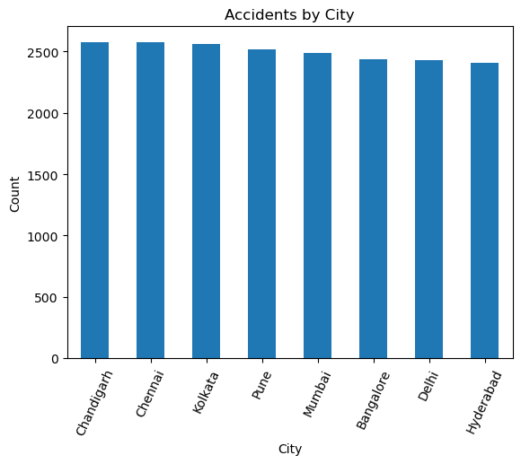

```python
plt.figure()
df['city'].value_counts().plot(kind='bar')
plt.title("Accidents by City")
plt.xlabel("City")
plt.ylabel("Count")
plt.xticks(rotation=65)
plt.show()
```

Most accident city is - Chandigarh, Chennai, and Kolkata

#### Accident Severity

[figure not shown]

```python
df['accident_severity'].value_counts().plot(kind='pie', autopct='%.1f%%')
plt.show()
```

This pie chart represents the percentage distribution of accident severity levels. Minor Accident:- 55.1% Major Accident:- 29.9% Spot death:- 14.9%

#### Accident by weather

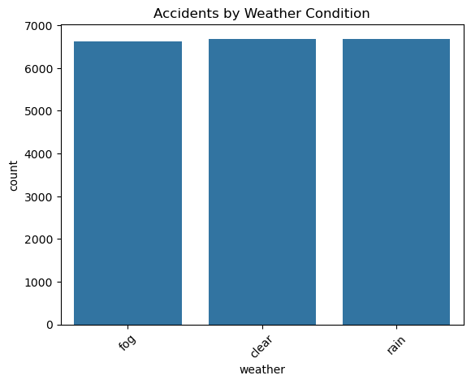

```python
plt.figure()
sns.countplot(x='weather', data=df)
plt.title("Accidents by Weather Condition")
plt.xticks(rotation=45)
plt.show()
```

This chart shows the count of each weather category

#### Accident by Road type

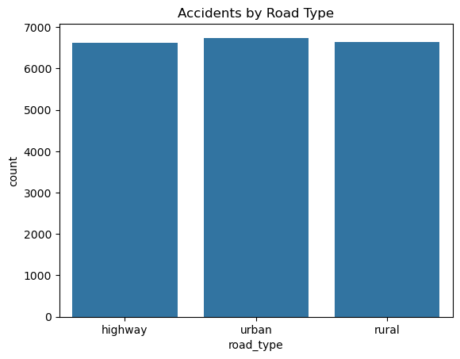

```python
plt.figure()
sns.countplot(x='road_type', data=df)
plt.title("Accidents by Road Type")
plt.show()
```

Accident hua tb road kaisi thi

Traffic density

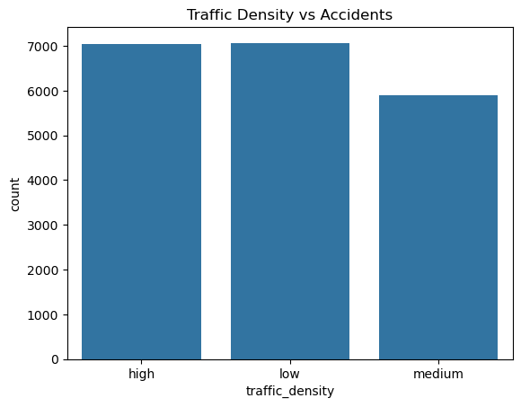

```python
plt.figure()
sns.countplot(x='traffic_density', data=df)
plt.title("Traffic Density vs Accidents")
plt.show()
```

Accident hua tb traffic kaise tha. Most of accident in high traffic and low traffic. Medium traffic me sabse kam accident huye hai.

Day of week

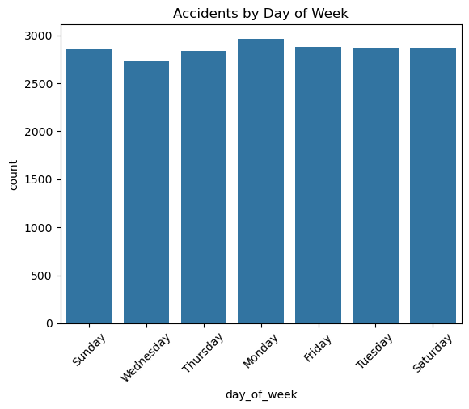

```python
plt.figure()
sns.countplot(x='day_of_week', data=df)
plt.title("Accidents by Day of Week")
plt.xticks(rotation=45)
plt.show()
```

Week ke kis din Sabse accident huye hai. Sabse jyada accident `Monday` ke din huye hai

Vehical involve

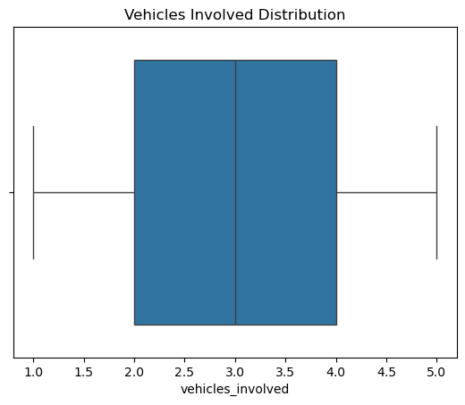

```python
plt.figure()
sns.boxplot(x=df['vehicles_involved'])
plt.title("Vehicles Involved Distribution")
plt.show()
```

Risk Score

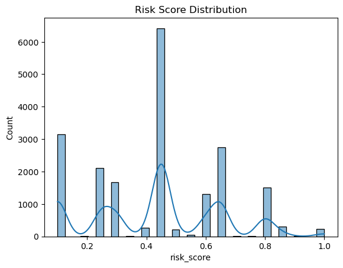

```python
plt.figure()
sns.histplot(df['risk_score'], kde=True)
plt.title("Risk Score Distribution")
plt.show()
```

The chart shows that accidents occurred even in `low-risk` areas, not only in `high-risk` zones.

[figure not shown]

```python
plt.figure()
sns.heatmap(df.corr(numeric_only=True), annot=True)
plt.title("Correlation Heatmap")
plt.show()
```

The heatmap shows how different factors are related to each other in the accident data.

Accident by Weekend

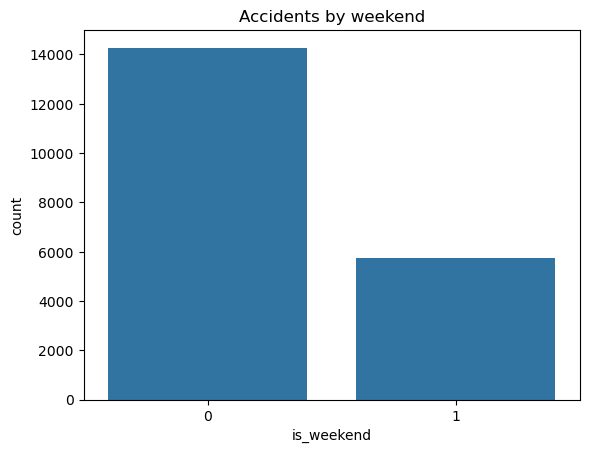

```python
plt.figure()
sns.countplot(x='is_weekend', data=df)
plt.title("Accidents by weekend")
plt.show()
```

1 = weekend (Saturday-Sunday). 0 = weekday (Monday to Friday). Sabse jyada accident `weekday's` me huye hai

Is peak hour

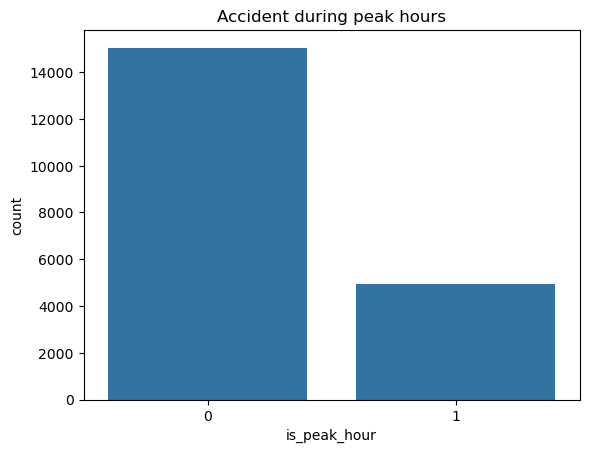

```python
plt.figure()
sns.countplot(x="is_peak_hour",data=df)
plt.title("Accident during peak hours")
plt.show()
```

1 = True → Peak hour (rush time) Usually: morning (8–10 AM) & evening (5–8 PM) 0 = False → Non-peak hour Sabse jyada accident `Non-peak-hours` me huye hai

#### Festival Impact

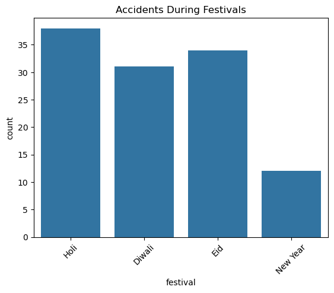

```python
plt.figure()
sns.countplot(x='festival', data=df)
plt.title("Accidents During Festivals")
plt.xticks(rotation=45)
plt.show()
```

Accident during festival. `Holi` me sabse jyada Accident

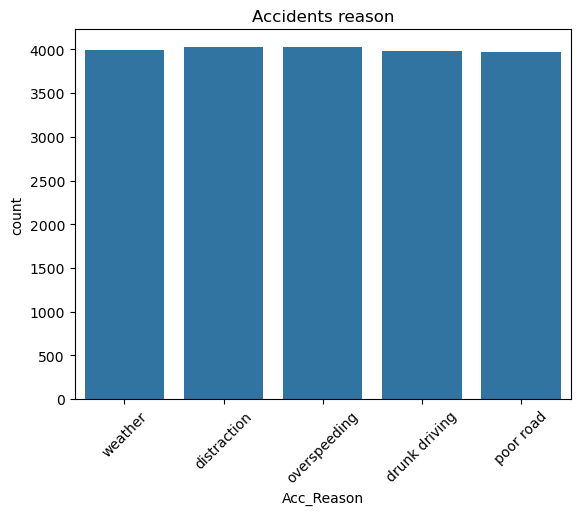

```python
plt.figure()
sns.countplot(x='Acc_Reason', data=df)
plt.title("Accidents reason")
plt.xticks(rotation=45)
plt.show()
```

### Accident reason

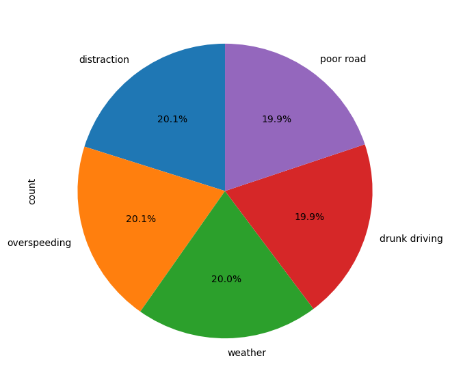

```python
plt.figure(figsize=(7,7))

df['Acc_Reason'].value_counts().plot(
    kind='pie',
    autopct='%1.1f%%',
    startangle=90)
```

This pie chart shows the reason behind accident Most of accident have occurred `distraction` and `OverSpeeding

## Project Conclusion

#### 3. Human Factors Are Critical

Major causes observed: Over-speeding Drunk driving Distraction Human behavior is a key contributor

#### 6. Severity Insights

Most accidents are: Minor But: Fatal cases increase in high-risk conditions

#### 7. Festival Impact

Slight increase in accidents during festivals Due to: More travel Rush & crowd